# Exercise and Feature Engineering II

In the first two parts we learned a lot about the general ML-workflow. We could achieve quite reasonable results for our classification task. We already performed some feature engineering and applied a transformation to an alternative representations of the RGB color model.

As mentioned before, deriving a meaningful and valid ML-model has to be an iterative process. Directly try to improve the ML-model by hyperparameter tuning is often not the first choice. So let’s go back to the feature engineering part.

Right now we use single color measurements of a marble to classify it. An easy way to improve the performance is to combine several measurements for each marble. In our example we will implement it by creating a tuple out of single measurements. Thereby, we will `stack` single samples to a single event.

```python
%matplotlib inline
```

```python
import os
import numpy as np
import pandas as pd
import zipfile
import matplotlib.pyplot as plt

from IPython.display import display, clear_output, Markdown
```

## Data Import, Preparation, Feature Engineering I

```python
def parse_lines(lines):
    """ Parse strings of marble data"""
    lines = lines[2:-2]
    rows = [d.split(', ') for d in lines.split('), (')]
    data = [[int(v.replace(')][(', '')) for v in r] for r in rows]
    return pd.DataFrame(data)[[0, 1, 2]]

files = [
    'blue-white-glass.data',
    'cyan-glass.data',
    'glass-blue.data',
    'glass-green.data',
    'glass-red.data',
    'glass-yellow.data',
    'planet-black-blue.data',
    'planet-green.data',
    'planet-ocean.data',
]

dfs = []
for i, fname in enumerate(files):
    print(f'Load data {i}: {fname}')

    with zipfile.ZipFile(f'../.assets/data/marbles/{fname}.zip', 'r') as zipf:
        with zipf.open(f'{fname}', 'r') as infile:
            content = infile.readlines()[0].decode()
            dfs.append(parse_lines(content).assign(color=f'{fname}'.replace('.data', '')))

df = pd.concat(dfs)
df.columns=['R', 'G', 'B', 'color']
```

```
Load data 0: blue-white-glass.data
Load data 1: cyan-glass.data
Load data 2: glass-blue.data
Load data 3: glass-green.data
Load data 4: glass-red.data
Load data 5: glass-yellow.data
Load data 6: planet-black-blue.data
Load data 7: planet-green.data
Load data 8: planet-ocean.data
```

```python
def generate_xy_values(df):
    df['X'] = 0.5 * np.sqrt(3) * df['G'] - 0.5 * np.sqrt(3) * df['B']
    df['Y'] = df['R'] - (1 / 3 * df['G']) - (1 / 3 * df['B'])

def generate_intensity_values(df):
    df['I'] = np.square(df['X']) + np.square(df['Y'])

def generate_angles(df):
    df['Phi'] = np.arctan2(df['Y'], df['X'])

# Feature Engineering I - we can add later
#generate_xy_values(df)
#generate_intensity_values(df)
#generate_angles(df)

# Add target ID
ids = {'blue-white-glass': 0,
      'cyan-glass': 1,
      'glass-blue': 2,
      'glass-green': 3,
      'glass-red': 4,
      'glass-yellow': 5,
      'planet-black-blue': 6,
      'planet-green': 7,
      'planet-ocean': 8,}

df['cat'] = df['color'].map(ids)

df.sample(5)
```

|  | R | G | B | color | cat |
| --- | --- | --- | --- | --- | --- |
| 33403 | 72 | 76 | 66 | glass-green | 3 |
| 11347 | 59 | 69 | 52 | glass-green | 3 |
| 85893 | 52 | 40 | 105 | glass-blue | 2 |
| 52795 | 60 | 36 | 22 | glass-red | 4 |
| 9580 | 64 | 72 | 63 | glass-green | 3 |

```python
df.shape
```

```
(900000, 5)
```

## Feature Engineering II

```python
# How many samples per event
VALUES_PER_EVENT = 15

# List of data sets
dfs = []

for i in range(9):

    # Get all samples of one type
    df_i = df[df['cat']==i]

    # Delete color and cat
    df_i = df_i.drop(labels=['cat'], axis=1)
    color = df_i.color[0]
    df_i = df_i.drop(labels=['color'], axis=1)

    # Create Package
    df_i['meas'] = (df_i.index.values / VALUES_PER_EVENT).astype('Int64')
    df_i['index'] = df_i.index % VALUES_PER_EVENT

    # Create mean
    rm = df_i.groupby('meas')['R'].mean()
    gm = df_i.groupby('meas')['G'].mean()
    bm = df_i.groupby('meas')['B'].mean()

    # Create standard deviations
    rv = df_i.groupby('meas')['R'].std()
    gv = df_i.groupby('meas')['G'].std()
    bv = df_i.groupby('meas')['B'].std()

    # Unstack
    df_i = df_i.set_index(['meas','index']).unstack(level=1)
    df_i.columns = [ f'{x}_{y}' for x in df_i.columns.levels[0] for y in df_i.columns.levels[1]]

    # Add mean and std
    df_i['R_M'] = rm
    df_i['G_M'] = gm
    df_i['B_M'] = bm

    df_i['R_V'] = rv
    df_i['G_V'] = gv
    df_i['B_V'] = bv

    # Add target
    df_i['cat'] = i
    df_i['color'] = color

    # Add to list of data sets
    dfs.append(df_i)

# Combine to one dataframe
df = pd.concat(dfs)
```

```python
df.shape
```

```
(60003, 53)
```

```python
df.columns
```

```
Index(['R_0', 'R_1', 'R_2', 'R_3', 'R_4', 'R_5', 'R_6', 'R_7', 'R_8', 'R_9',
       'R_10', 'R_11', 'R_12', 'R_13', 'R_14', 'G_0', 'G_1', 'G_2', 'G_3',
       'G_4', 'G_5', 'G_6', 'G_7', 'G_8', 'G_9', 'G_10', 'G_11', 'G_12',
       'G_13', 'G_14', 'B_0', 'B_1', 'B_2', 'B_3', 'B_4', 'B_5', 'B_6', 'B_7',
       'B_8', 'B_9', 'B_10', 'B_11', 'B_12', 'B_13', 'B_14', 'R_M', 'G_M',
       'B_M', 'R_V', 'G_V', 'B_V', 'cat', 'color'],
      dtype='object')
```

```python
df.sample(5)
```

| meas | R_0 | R_1 | R_2 | R_3 | R_4 | R_5 | R_6 | R_7 | R_8 | R_9 | ... | B_13 | B_14 | R_M | G_M | B_M | R_V | G_V | B_V | cat | color |
| --- | --- | --- | --- | --- | --- | --- | --- | --- | --- | --- | --- | --- | --- | --- | --- | --- | --- | --- | --- | --- | --- |
| 5788 | 37.0 | 28.0 | 22.0 | 26.0 | 27.0 | 32.0 | 35.0 | 46.0 | 56.0 | 62.0 | ... | 39.0 | 46.0 | 45.600000 | 67.200000 | 17.533333 | 16.590875 | 23.634720 | 11.550304 | 8 | planet-ocean |
| 4090 | 27.0 | 30.0 | 29.0 | 30.0 | 26.0 | 27.0 | 25.0 | 24.0 | 25.0 | 25.0 | ... | 19.0 | 13.0 | 26.000000 | 32.333333 | 18.333333 | 2.203893 | 2.526055 | 5.287001 | 0 | blue-white-glass |
| 328 | 26.0 | 24.0 | 22.0 | 22.0 | 22.0 | 22.0 | 19.0 | 20.0 | 19.0 | 19.0 | ... | 19.0 | 21.0 | 19.000000 | 41.066667 | 45.600000 | 4.276180 | 8.154461 | 19.881075 | 1 | cyan-glass |
| 649 | 29.0 | 31.0 | 31.0 | 31.0 | 34.0 | 36.0 | 37.0 | 36.0 | 36.0 | 36.0 | ... | 49.0 | 41.0 | 31.800000 | 79.466667 | 42.400000 | 4.178175 | 15.477480 | 17.191360 | 8 | planet-ocean |
| 5406 | 25.0 | 26.0 | 27.0 | 25.0 | 26.0 | 24.0 | 24.0 | 21.0 | 17.0 | 15.0 | ... | 5.0 | 5.0 | 17.333333 | 24.200000 | 18.800000 | 9.092121 | 11.905581 | 11.515207 | 0 | blue-white-glass |

5 rows × 53 columns

```python
# Mix data set
df = df.sample(frac=1)
```

### Start with ML

- Your task is to built up the ML workflow. Start with defining the training features, set up training and test data set, import relevant modules...
- You may want to give it another try with unsupervised learning (e.g. Gaussian Mixture)!

```python
 # It's your turn!

training_features = []
target = ['']

X = []
y = []

#......
```

# Sample solution

```python
from sklearn.model_selection import train_test_split

from sklearn.ensemble import RandomForestClassifier
from sklearn.neural_network import MLPClassifier

from sklearn.metrics import confusion_matrix
from sklearn.metrics import roc_curve, roc_auc_score
from sklearn.model_selection import cross_val_score
```

```python
training_features = [c  for c in df.columns if (('R' in c) or ('G' in c) or ('B' in c))]

target = ['cat']

X = df[training_features + target].dropna()
y = X[target]
X.drop(target, axis=1, inplace=True)

X_train, X_test, y_train, y_test = train_test_split(X, y, test_size=0.2)
```

```python
model = RandomForestClassifier(n_estimators=10, max_depth=10) # Start
#model = RandomForestClassifier(n_estimators=100, max_depth=None) # TOP
```

```python
# Fit des Modells
model.fit(X_train, y_train.values[:,0])
```

```
RandomForestClassifier(bootstrap=True, class_weight=None, criterion='gini',
            max_depth=10, max_features='auto', max_leaf_nodes=None,
            min_impurity_decrease=0.0, min_impurity_split=None,
            min_samples_leaf=1, min_samples_split=2,
            min_weight_fraction_leaf=0.0, n_estimators=10, n_jobs=None,
            oob_score=False, random_state=None, verbose=0,
            warm_start=False)
```

## Validation

### Confusion matrix

```python
y_pred_test = model.predict(X_test)
truth = y_test
cm = confusion_matrix(truth,y_pred_test)

pd.DataFrame(data=cm)
```

|  | 0 | 1 | 2 | 3 | 4 | 5 | 6 | 7 | 8 |
| --- | --- | --- | --- | --- | --- | --- | --- | --- | --- |
| 0 | 1151 | 21 | 1 | 70 | 0 | 16 | 22 | 0 | 8 |
| 1 | 0 | 1300 | 1 | 18 | 0 | 0 | 11 | 0 | 1 |
| 2 | 7 | 0 | 1346 | 1 | 0 | 0 | 0 | 0 | 0 |
| 3 | 37 | 1 | 0 | 1308 | 0 | 0 | 0 | 1 | 4 |
| 4 | 0 | 0 | 0 | 0 | 1341 | 0 | 0 | 0 | 0 |
| 5 | 9 | 0 | 0 | 74 | 0 | 1302 | 0 | 0 | 2 |
| 6 | 128 | 53 | 0 | 0 | 0 | 0 | 1162 | 0 | 7 |
| 7 | 0 | 0 | 0 | 3 | 0 | 0 | 0 | 1283 | 3 |
| 8 | 88 | 119 | 0 | 6 | 3 | 37 | 29 | 0 | 1025 |

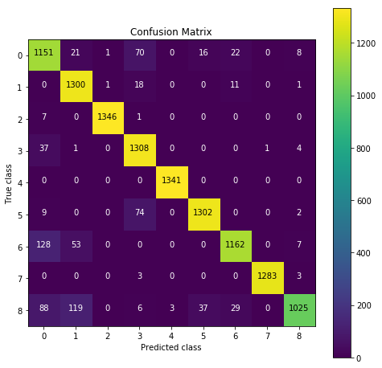

```python
import itertools

plt.figure(figsize=(8, 8))
plt.imshow(cm, interpolation='nearest', cmap='viridis',vmin=0, vmax=df.shape[0]/9*0.2)
plt.colorbar()
for i, j in itertools.product(range(9), range(9)):
        plt.text(j, i, f'{cm[i, j]:.0f}', horizontalalignment="center",color="white" if not i==j else "black")
plt.title('Confusion Matrix')
plt.ylabel('True class')
plt.xlabel('Predicted class');
```

### Hypothesis test

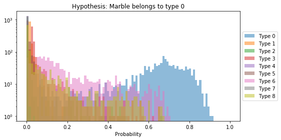

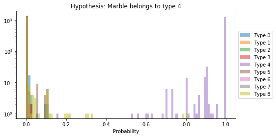

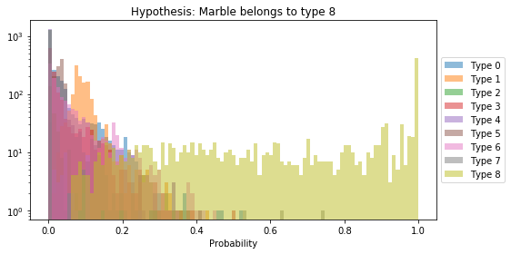

```python
#cat = [0,1,2,3,4,5,6,7,8]
cat = [0, 4, 8]

y_proba_test = model.predict_proba(X_test)

for i in cat:
    y_proba_test_i = y_proba_test[:,i]
    plt.figure(figsize=(8, 4))

    for j in range(9):
        plt.hist(y_proba_test_i[y_test['cat'] == j],
                 bins=np.linspace(0,1,100),
                 alpha=0.5,
                 normed=False,
                 label=f'Type {j}')

    plt.title(f'Hypothesis: Marble belongs to type {i}')
    plt.xlabel('Probability')
    plt.legend(loc='center left', bbox_to_anchor=(1, 0.5))
    plt.tight_layout()
    plt.yscale('log', nonposy='clip')
    plt.show()
```

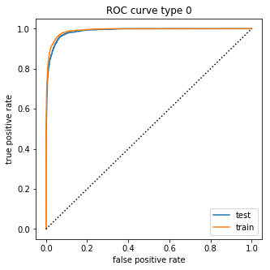

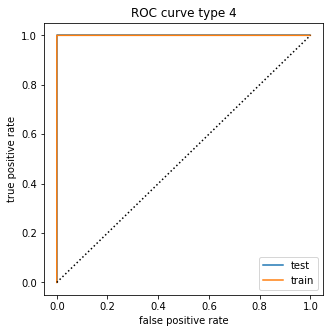

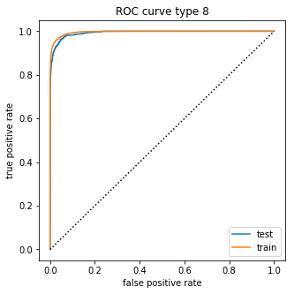

```python
#cat = [0,1,2,3,4,5,6,7,8]
cat = [0, 4, 8]

y_proba_test = model.predict_proba(X_test)
y_proba_train = model.predict_proba(X_train)

for i in cat:
    y_proba_test_i = y_proba_test[:,i]
    y_proba_train_i = y_proba_train[:,i]

    plt.figure(figsize=(5, 5))
    plt.plot(*roc_curve(y_test == i, y_proba_test_i)[:2], label='test')
    plt.plot(*roc_curve(y_train == i, y_proba_train_i)[:2], label='train')
    plt.plot([0, 1],[0, 1], color='black', linestyle=':')
    plt.title(f'ROC curve type {i}')
    plt.xlabel('false positive rate')
    plt.ylabel('true positive rate')
    plt.legend(loc='best')
    plt.show();
```

### Feature Importance

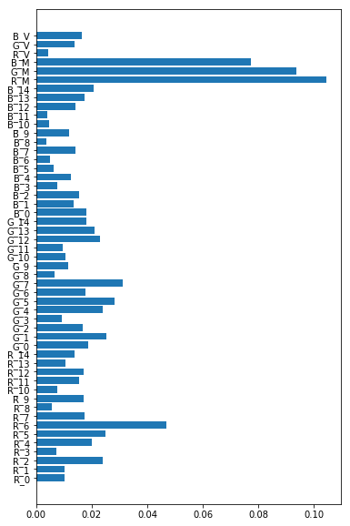

```python
plt.figure(figsize=(6, 10))
plt.barh(range(len(X.columns)), model.feature_importances_)
plt.yticks(range(len(X.columns)), X.columns)
plt.show()
```

### AUC and Accuracy

```python
data=[]
for i in range(9):
    y_proba_test_i = y_proba_test[:,i]
    data.append(roc_auc_score(y_test.values == i, y_proba_test_i))

# Displaying
pd.DataFrame(np.array(data), columns=['AUC'])
```

|  | AUC |
| --- | --- |
| 0 | 0.987462 |
| 1 | 0.998028 |
| 2 | 0.999995 |
| 3 | 0.997327 |
| 4 | 0.999997 |
| 5 | 0.998955 |
| 6 | 0.995138 |
| 7 | 0.999855 |
| 8 | 0.993233 |

```python
print(f'Mean Accuracy: {model.score(X_test, y_test):.3f}')
```

```
Mean Accuracy: 0.935
```

## Unsupervised learning with Gaussian Mixture

```python
import matplotlib.cm as cm
cmap = cm.get_cmap('Set1')
```

```python
cat = [0,1,2,3,4,5,6,7,8]

X = df[df['cat'].isin(cat)][['R_M','G_M','B_M','R_V','B_V','G_V','cat']]

# Reduced data set size
X = X.sample(10000)

# Define target for visualiztion
target = X['cat']
X=X.drop(['cat'],axis=1).as_matrix()
```

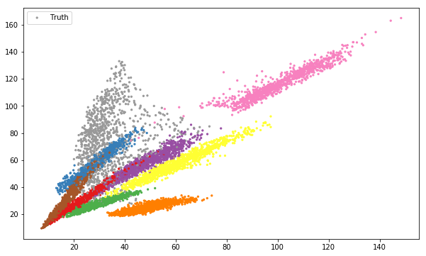

```python
# Raw data
plt.figure(figsize=(10, 6))
plt.scatter(X[:, 0], X[:, 1], color=cmap(target), s=5, label ='Truth')
plt.legend();
```

```python
from sklearn.mixture import GaussianMixture
model = GaussianMixture(n_components=9, init_params='kmeans')
model.fit(X)
predictions = model.predict(X)
```

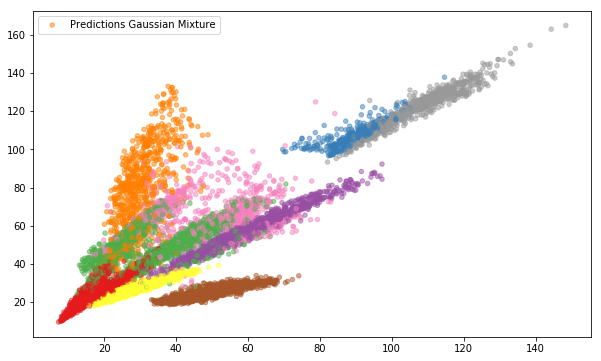

```python
plt.figure(figsize=(10, 6))
plt.scatter(X[:, 0], X[:, 1], s=20, color = cmap(predictions), alpha=0.5, label='Predictions Gaussian Mixture')
plt.legend();
```

*This notebook is licensed under a [Creative Commons Attribution 4.0 International License (CC BY 4.0)](https://creativecommons.org/licenses/by/4.0/). Copyright © 2018 [Point 8 GmbH](https://point-8.de)*